# Analiza danych o postępach uczniów szkoły średniej

Poniższa analiza opiera się o dane zebrane w portugalskiej szkole im. Gabriela Pereiry w mieście Évora. Dane zebrane zostały w celu określenia czynników wpływających na wysokość końcowej oceny z matematyki uzyskanej przez ucznia. Do dyspozycji mamy następujące zmienne:

1) school - szkoła - nazwa szkoły, z której pochodzą dane (analizie poddana zostanie tylko szkoła GP)

2) sex - płeć ucznia - przez "F" zakodowano kobiety, a przez "M" mężczyzn

3) age - wiek ucznia - w latach

4) address - miejsce zamieszkania - przez "U" zakodowano ucznia mieszkającego w mieście, przez "R" ucznia ze wsi

5) famsize - liczba osób w rodzinie - "LE3" oznacza, że rodzina ucznia liczy 3 osoby lub mniej, "GT3" oznacza przynajmniej 3 osoby

6) Pstatus - status rodziców ucznia - "T" oznacza, że rodzice żyją razem, "A" oznacza, że żyją osobno

7) Medu - edukacja matki ucznia - kodowanie: "0" - brak jakiegokolwiek wykształcenia, "1" - skończone pierwsze 4 klasy, "2" – skończone 5 do 9 klas, "3" – wykształcenie średnie, "4" – wykształcenie wyższe

8) Fedu - edukacja ojca ucznia - kodowanie: "0" - brak jakiegokolwiek wykształcenia, "1" - skończone pierwsze 4 klasy, "2" – skończone 5 do 9 klas, "3" – wykształcenie średnie, "4" – wykształcenie wyższe

9) Mjob - praca matki - możliwe wartości: "teacher" - nauczyciel, "health" - praca w służbie zdrowia, "services" - służby publiczne, "at_home" - w domu, "other" - inny zawód

10) Fjob - praca ojca - możliwe wartości: "teacher" - nauczyciel, "health" - praca w służbie zdrowia, "services" - służby publiczne, "at_home" - w domu, "other" - inny zawód

11) reason - główny powód wyboru szkoły przez ucznia - możliwe wartości: "home" - blisko domu, "reputation" - reputacja szkoły, "course" - oferta edukacyjna szkoły, "other" - inny powód

12) guardian - opiekun prawny ucznia - możliwe wartości: "mother" - matka, "father" - ojciec, "other" - inna osoba

13) traveltime - czas podróży z domu do szkoły - kodowanie: "1" - do 15 minut, "2" - 15 do 30 minut, "3" - 30 do 60 minut, "4" - powyżej 1 godziny

14) studytime - czas spędzony na nauce tygodniowo - kodowanie: "1" - poniżej 2 godzin, "2" - 2 do 5 godzin, "3" - 5 do 10 godzin, "4" - powyżej 10 godzin

15) failures - liczba oblanych przedmiotów przez ucznia do momentu badania (nie zostało sprecyzowane czy chodzi tylko o matematykę) - kodowanie: "1" - 1 powtórka, "2" - 2 powtórki, "3" - 3 powtórki, "4" - uczeń oblał więcej niż 3 razy

16) schoolsup - informacja o korzystaniu z dodatkowej pomocy edukacyjnej - kodowanie: "yes" - tak, "no" - nie

17) famsup - informacja o dodatkowym wsparciu materialnym rodziny ucznia - kodowanie: "yes" - tak, "no" - nie

18) paid - informacja o korzystaniu z dodatkowych płatnych lekcji matematyki - kodowanie: "yes" - tak, "no" - nie

19) activities - informacja o uczęszczaniu na dodatkowe zajęcia pozalekcyjne - kodowanie: "yes" - tak, "no" - nie

20) nursery - informacja o tym, czy uczeń chodził do żłobka - kodowanie: "yes" - tak, "no" - nie

21) higher - informacja czy uczeń planuje iść na studia - kodowanie: "yes" - tak, "no" - nie

22) internet - informacja o dostępie do Internetu przez ucznia w domu - kodowanie: "yes" - tak, "no" - nie

23) romantic - informacja, czy uczeń był w czasie badania w związku (czy ma partnera) - kodowanie: "yes" - tak, "no" - nie

24) famrel - jakość stosunków rodzinnych - kodowanie: "5" - doskonałe, "4"- dobre, "3" - średnie, "2" - złe, "1"- bardzo złe

25) freetime - ilość wolnego czasu ucznia - kodowanie: "5" - bardzo dużo, "4" - dużo, "3" - średnio, "2" - mało, "1"- bardzo mało

26) goout - częstość spotykania się ze znajomymi - kodowanie: "5" - bardzo często, "4" - często, "3" - czasami, "2" - rzadko, "1"- bardzo rzadko

27) Dalc - spożycie alkoholu przez ucznia w tygodniu (poniedziałek - piątek) - kodowanie: "5" - bardzo duże, "4" - duże, "3" - średnie, "2" - małe, "1"- bardzo małe

28) Walc - spożycie alkoholu przez ucznia podczas weekendu - kodowanie: "5" - bardzo duże, "4" - duże, "3" - średnie, "2" - małe, "1"- bardzo małe

29) health - ogólna samoocena zdrowia ucznia w momencie badań - "5" - doskonałe, "4" - dobre, "3" - średnie, "2" - złe, "1" - bardzo złe

30) absences - liczba nieobecności ucznia w roku szkolnym

31) G1 - liczba punktów (ocena) za pierwszy semestr - wartość między 0 a 20

32) G2 - liczba punktów (ocena) za drugi semestr - wartość między 0 a 20

33) G3 - końcowa liczba punktów (ocena) - wartość między 0 a 20

W tym raporcie analizie zostanie wykonany przegląd wszystkich powyższych pomiarów. Głównym zainteresowaniem będą tutaj informacje dotyczące słabszych uczniów. Przyjęte zostało, że słabszy uczeń to taki, którego ocena końcowa, G3, była mniejsza od 10.

Następnie podjęta zostanie próba porównania ze sobą średnich wartości ocen G1, G2 i G3. Celem będzie sprawdzenie, czy różnice między nimi są statystycznie istotne.

Kolejnym krokiem będzie budowa modelu, którego zadaniem będzie przewidzenie wartości G3 ucznia, przy użyciu innych dostępnych informacji o nim, lecz bez użycia G1 i G2. Jest to główny powód, dla którego zebrano użyte tutaj dane.

Dodatkowym, ostatnim elementem tego raportu będzie analiza skupień. Z jej pomocą zostanie zaproponowana inna definicja ucznia słabszego.

```python
import pandas as pd
import numpy as np
import matplotlib as mpl
import matplotlib.pyplot as plt
import seaborn as sns
import datetime, nltk, warnings
import matplotlib.cm as cm
from sklearn.preprocessing import StandardScaler
from sklearn.cluster import KMeans
from sklearn.metrics import silhouette_samples, silhouette_score
from scipy import stats
import scikit_posthocs
import plotly.express as px
import plotly.graph_objs as go
from plotly.offline import init_notebook_mode,iplot
init_notebook_mode(connected=True)
warnings.filterwarnings("ignore")
plt.rcParams["patch.force_edgecolor"] = True
plt.style.use('fivethirtyeight')
mpl.rc('patch', edgecolor = 'dimgray', linewidth=1)
%matplotlib inline
from plotly.subplots import make_subplots

from sklearn.compose import ColumnTransformer
from sklearn.pipeline import Pipeline
from sklearn.impute import SimpleImputer
from sklearn.preprocessing import OneHotEncoder
from sklearn.ensemble import RandomForestRegressor
from sklearn.metrics import mean_absolute_error
from sklearn.model_selection import train_test_split
from xgboost import XGBRegressor
from sklearn.metrics import mean_squared_error
from sklearn.model_selection import RandomizedSearchCV
from sklearn.cluster import KMeans
```

## Przygotowanie danych

```python
pd.set_option('display.max_columns', None)
dane = pd.read_csv("student-mat.csv",delimiter=';')
```

Wynik komórki poniżej pokazuje, że dane nie posiadają żadnych braków.

```python
braki_danych = [col for col in dane.columns
                     if dane[col].isnull().any()]
print(braki_danych)
```

```
[]
```

```python
dane.head(5)
```

|  | school | sex | age | address | famsize | Pstatus | Medu | Fedu | Mjob | Fjob | reason | guardian | traveltime | studytime | failures | schoolsup | famsup | paid | activities | nursery | higher | internet | romantic | famrel | freetime | goout | Dalc | Walc | health | … |
| --- | --- | --- | --- | --- | --- | --- | --- | --- | --- | --- | --- | --- | --- | --- | --- | --- | --- | --- | --- | --- | --- | --- | --- | --- | --- | --- | --- | --- | --- | --- |
| 0 | GP | F | 18 | U | GT3 | A | 4 | 4 | at_home | teacher | course | mother | 2 | 2 | 0 | yes | no | no | no | yes | yes | no | no | 4 | 3 | 4 | 1 | 1 | 3 | … |
| 1 | GP | F | 17 | U | GT3 | T | 1 | 1 | at_home | other | course | father | 1 | 2 | 0 | no | yes | no | no | no | yes | yes | no | 5 | 3 | 3 | 1 | 1 | 3 | … |
| 2 | GP | F | 15 | U | LE3 | T | 1 | 1 | at_home | other | other | mother | 1 | 2 | 3 | yes | no | yes | no | yes | yes | yes | no | 4 | 3 | 2 | 2 | 3 | 3 | … |
| 3 | GP | F | 15 | U | GT3 | T | 4 | 2 | health | services | home | mother | 1 | 3 | 0 | no | yes | yes | yes | yes | yes | yes | yes | 3 | 2 | 2 | 1 | 1 | 5 | … |
| 4 | GP | F | 16 | U | GT3 | T | 3 | 3 | other | other | home | father | 1 | 2 | 0 | no | yes | yes | no | yes | yes | no | no | 4 | 3 | 2 | 1 | 2 | 5 | … |

Należy jeszcze sprawdzić, czy otrzymane dane nie zawierają oczywistych błędów. Wynik poniższej komórki pokazuje, że dane są prawidłowe.

```python
for column in dane.columns:
     print("\n" + column)
     print(dane[column].value_counts().sort_index(ascending=True))
```

```
school
GP    349
MS     46
Name: school, dtype: int64

sex
F    208
M    187
Name: sex, dtype: int64

age
15     82
16    104
17     98
18     82
19     24
20      3
21      1
22      1
Name: age, dtype: int64

address
R     88
U    307
Name: address, dtype: int64

famsize
GT3    281
LE3    114
Name: famsize, dtype: int64

Pstatus
A     41
T    354
Name: Pstatus, dtype: int64

Medu
0      3
1     59
2    103
```

[output cut: 232 more lines]

```
7      9
8     32
9     28
10    56
11    47
12    31
13    31
14    27
15    33
16    16
17     6
18    12
19     5
20     1
Name: G3, dtype: int64
```

```python
fig = go.Figure(data=[go.Pie(labels=['Gabriel Pereira', 'Mousinho da Silveira'], values=dane['school'].value_counts())])

fig.update_traces(hoverinfo='label+value', textinfo='percent')

fig.update_layout(
    title_text="Szkoła")
fig.show()
```

[interactive chart not shown]

Powyższy wykres kołowy pokazuje, uczniowie szkoły im. Gabriela Pereiry stanowią aż 88% całego zbioru danych. Z tego powodu rozważane będą tylko dane pochodzące z tej szkoły. Usunięte zostaną zatem 46 obserwacje należące do szkoły zakodowanej przez "MS".

```python
dane = dane[dane.school == 'GP']
dane = dane.drop('school', 1)
```

Na potrzeby wizualizacji i dalszego modelowania stworzono drugi zbiór danych, w którym skorzystano z dummy variables jako kodowanie binarnych zmiennych.

```python
dummy_cols = [cname for cname in dane.columns if
                    dane[cname].nunique() ==2  and
                    dane[cname].dtype == "object"]

student=pd.get_dummies(dane,columns=dummy_cols,drop_first=True)
```

```python
student.loc[student.guardian=='other','guardian']=0
student.loc[student.guardian!=0,'guardian']=1
student=student.rename(columns={"guardian":"guardianParent"})
student = student.astype({"guardianParent": int})
```

```python
student.columns
```

```
Index(['age', 'Medu', 'Fedu', 'Mjob', 'Fjob', 'reason', 'guardianParent',
       'traveltime', 'studytime', 'failures', 'famrel', 'freetime', 'goout',
       'Dalc', 'Walc', 'health', 'absences', 'G1', 'G2', 'G3', 'sex_M',
       'address_U', 'famsize_LE3', 'Pstatus_T', 'schoolsup_yes', 'famsup_yes',
       'paid_yes', 'activities_yes', 'nursery_yes', 'higher_yes',
       'internet_yes', 'romantic_yes'],
      dtype='object')
```

```python
student.describe()
```

|  | age | Medu | Fedu | guardianParent | traveltime | studytime | failures | famrel | freetime | goout | Dalc | Walc | health | absences | G1 | G2 | G3 | sex_M | address_U | famsize_LE3 | Pstatus_T | schoolsup_yes | famsup_yes | paid_yes | activities_yes | nursery_yes | higher_yes | internet_yes | romantic_yes |
| --- | --- | --- | --- | --- | --- | --- | --- | --- | --- | --- | --- | --- | --- | --- | --- | --- | --- | --- | --- | --- | --- | --- | --- | --- | --- | --- | --- | --- | --- |
| count | 349.00000 | 349.000000 | 349.000000 | 349.000000 | 349.000000 | 349.000000 | 349.000000 | 349.000000 | 349.000000 | 349.000000 | 349.000000 | 349.000000 | 349.000000 | 349.000000 | 349.000000 | 349.000000 | 349.000000 | 349.000000 | 349.000000 | 349.000000 | 349.000000 | 349.000000 | 349.000000 | 349.000000 | 349.000000 | 349.000000 | 349.000000 | 349.000000 | 349.000000 |
| mean | 16.52149 | 2.802292 | 2.553009 | 0.925501 | 1.386819 | 2.063037 | 0.318052 | 3.959885 | 3.223496 | 3.111748 | 1.444126 | 2.260745 | 3.575931 | 5.965616 | 10.939828 | 10.782235 | 10.489971 | 0.475645 | 0.819484 | 0.277937 | 0.891117 | 0.146132 | 0.641834 | 0.461318 | 0.530086 | 0.808023 | 0.951289 | 0.851003 | 0.323782 |
| std | 1.21661 | 1.068566 | 1.080482 | 0.262958 | 0.666910 | 0.851998 | 0.734409 | 0.873358 | 0.986354 | 1.122704 | 0.857959 | 1.307881 | 1.382607 | 8.341764 | 3.319109 | 3.808434 | 4.625397 | 0.500123 | 0.385169 | 0.448625 | 0.311939 | 0.353745 | 0.480150 | 0.499217 | 0.499811 | 0.394421 | 0.215571 | 0.356597 | 0.468590 |
| min | 15.00000 | 0.000000 | 0.000000 | 0.000000 | 1.000000 | 1.000000 | 0.000000 | 1.000000 | 1.000000 | 1.000000 | 1.000000 | 1.000000 | 1.000000 | 0.000000 | 3.000000 | 0.000000 | 0.000000 | 0.000000 | 0.000000 | 0.000000 | 0.000000 | 0.000000 | 0.000000 | 0.000000 | 0.000000 | 0.000000 | 0.000000 | 0.000000 | 0.000000 |
| 25% | 16.00000 | 2.000000 | 2.000000 | 1.000000 | 1.000000 | 1.000000 | 0.000000 | 4.000000 | 3.000000 | 2.000000 | 1.000000 | 1.000000 | 3.000000 | 0.000000 | 8.000000 | 9.000000 | 8.000000 | 0.000000 | 1.000000 | 0.000000 | 1.000000 | 0.000000 | 0.000000 | 0.000000 | 0.000000 | 1.000000 | 1.000000 | 1.000000 | 0.000000 |
| 50% | 16.00000 | 3.000000 | 3.000000 | 1.000000 | 1.000000 | 2.000000 | 0.000000 | 4.000000 | 3.000000 | 3.000000 | 1.000000 | 2.000000 | 4.000000 | 4.000000 | 11.000000 | 11.000000 | 11.000000 | 0.000000 | 1.000000 | 0.000000 | 1.000000 | 0.000000 | 1.000000 | 0.000000 | 1.000000 | 1.000000 | 1.000000 | 1.000000 | 0.000000 |
| 75% | 17.00000 | 4.000000 | 3.000000 | 1.000000 | 2.000000 | 2.000000 | 0.000000 | 5.000000 | 4.000000 | 4.000000 | 2.000000 | 3.000000 | 5.000000 | 8.000000 | 13.000000 | 13.000000 | 14.000000 | 1.000000 | 1.000000 | 1.000000 | 1.000000 | 0.000000 | 1.000000 | 1.000000 | 1.000000 | 1.000000 | 1.000000 | 1.000000 | 1.000000 |
| max | 22.00000 | 4.000000 | 4.000000 | 1.000000 | 4.000000 | 4.000000 | 3.000000 | 5.000000 | 5.000000 | 5.000000 | 5.000000 | 5.000000 | 5.000000 | 75.000000 | 19.000000 | 19.000000 | 20.000000 | 1.000000 | 1.000000 | 1.000000 | 1.000000 | 1.000000 | 1.000000 | 1.000000 | 1.000000 | 1.000000 | 1.000000 | 1.000000 | 1.000000 |

```python
student.head(5)
```

|  | age | Medu | Fedu | Mjob | Fjob | reason | guardianParent | traveltime | studytime | failures | famrel | freetime | goout | Dalc | Walc | health | absences | G1 | G2 | G3 | sex_M | address_U | famsize_LE3 | Pstatus_T | schoolsup_yes | famsup_yes | paid_yes | activities_yes | nursery_yes | … |
| --- | --- | --- | --- | --- | --- | --- | --- | --- | --- | --- | --- | --- | --- | --- | --- | --- | --- | --- | --- | --- | --- | --- | --- | --- | --- | --- | --- | --- | --- | --- |
| 0 | 18 | 4 | 4 | at_home | teacher | course | 1 | 2 | 2 | 0 | 4 | 3 | 4 | 1 | 1 | 3 | 6 | 5 | 6 | 6 | 0 | 1 | 0 | 0 | 1 | 0 | 0 | 0 | 1 | … |
| 1 | 17 | 1 | 1 | at_home | other | course | 1 | 1 | 2 | 0 | 5 | 3 | 3 | 1 | 1 | 3 | 4 | 5 | 5 | 6 | 0 | 1 | 0 | 1 | 0 | 1 | 0 | 0 | 0 | … |
| 2 | 15 | 1 | 1 | at_home | other | other | 1 | 1 | 2 | 3 | 4 | 3 | 2 | 2 | 3 | 3 | 10 | 7 | 8 | 10 | 0 | 1 | 1 | 1 | 1 | 0 | 1 | 0 | 1 | … |
| 3 | 15 | 4 | 2 | health | services | home | 1 | 1 | 3 | 0 | 3 | 2 | 2 | 1 | 1 | 5 | 2 | 15 | 14 | 15 | 0 | 1 | 0 | 1 | 0 | 1 | 1 | 1 | 1 | … |
| 4 | 16 | 3 | 3 | other | other | home | 1 | 1 | 2 | 0 | 4 | 3 | 2 | 1 | 2 | 5 | 4 | 6 | 10 | 10 | 0 | 1 | 0 | 1 | 0 | 1 | 1 | 0 | 1 | … |

```python
dane.loc[dane.Medu==0,"Medu"]='Brak wykształcenia'
dane.loc[dane.Medu==1,"Medu"]='4 klasy'
dane.loc[dane.Medu==2,"Medu"]='5-9 klas'
dane.loc[dane.Medu==3,"Medu"]='Średnie'
dane.loc[dane.Medu==4,"Medu"]='Wyższe'

dane.loc[dane.Fedu==0,"Fedu"]='Brak wykształcenia'
dane.loc[dane.Fedu==1,"Fedu"]='4 klasy'
dane.loc[dane.Fedu==2,"Fedu"]='5-9 klas'
dane.loc[dane.Fedu==3,"Fedu"]='Średnie'
dane.loc[dane.Fedu==4,"Fedu"]='Wyższe'
```

## Wyniki z każdego z etapów - G1, G2, G3

```python
fig = go.Figure(data=[go.Histogram(x=dane.G1)])



fig.update_layout(
    title_text="Rozkład wyników G1",
     xaxis_title_text='Wynik',
     yaxis_title_text='Liczba osób')


fig.show()
```

[interactive chart not shown]

```python
fig = go.Figure(data=[go.Histogram(x=dane.G2)])

fig.update_layout(
    title_text="Rozkład wyników G2",
     xaxis_title_text='Wynik',
     yaxis_title_text='Liczba osób')


fig.show()
```

[interactive chart not shown]

```python
fig = go.Figure(data=[go.Histogram(x=dane.G3)])

fig.update_layout(
    title_text="Rozkład wyników G3",
    xaxis_title_text='Wynik',
    yaxis_title_text='Liczba osób')


fig.show()
```

[interactive chart not shown]

```python
fig = go.Figure()
fig.add_trace(go.Histogram(x=dane.G1,opacity=0.5,name="G1"))
fig.add_trace(go.Histogram(x=dane.G2,opacity=0.5,name="G2"))
fig.add_trace(go.Histogram(x=dane.G3,opacity=0.5,name="G3"))

fig.update_layout(
    title_text="Rozkład wyników wszystkich etapów",
    xaxis_title_text='Wynik',
    yaxis_title_text='Liczba osób',
    barmode='overlay')


fig.show()
```

[interactive chart not shown]

Z przedstawionych histogramów można wyciągnąć kilka wniosków. Aż 34 osoby otrzymały 0 punktów jako ocenę końcową. Liczba ta stanowi prawie 10% wszystkich uczniów biorących udział w badaniu. Wyniki G1 są rozłożone bardziej równomiernie w porównaniu do G2 i G3. Poza oczywistym wyjątkiem dla wartości 0, wykresy G1, G2 i G3 wydają się przedstawiać trend, w którym uczniowie uzyskiwali coraz lepsze wyniki wraz ze zbliżającym się końcem roku szkolnego. Gdyby uczniowie nie rezygnowali w trakcie semestru, histogram wyników G3 prawdopodobnie przedstawiałby rozkład normalny ze średnią 10. Z tego też wykresu można zgadywać, że próg zaliczenia roku wynosił 7-8 punktów.

Jednym z ciekawszych problemów może okazać się identyfikacja cech, które wyróżniają osoby słabsze od reszty grupy. W tym raporcie przez osobę słabszą rozumiany będzie uczeń, który osiągnął mniej niż 10 punktów jako ocena końcowa G3.

```python
daneS=dane[dane.G3<10]
studentS=student[student.G3<10]
```

## Ogólne informacje dotyczące uczniów

```python
labels = ['Kobieta', 'Mężczyzna']



fig = make_subplots(rows=1, cols=2, specs=[[{'type':'domain'}, {'type':'domain'}]])
fig.add_trace(go.Pie(labels=labels, values=dane['sex'].value_counts(), name="Cała szkoła GP"),
              1, 1)
fig.add_trace(go.Pie(labels=labels, values=daneS['sex'].value_counts(), name="Słabsi uczniowie z GP"),
              1, 2)


fig.update_traces(hole=.4, hoverinfo="label+value+name")

fig.update_layout(
    title_text="Rozkład płci w szkole GP - cała szkoła oraz tylko słabsi uczniowie",

    annotations=[dict(text='Wszyscy', x=0.16, y=0.5, font_size=20, showarrow=False),
                 dict(text='Słabsi', x=0.82, y=0.5, font_size=20, showarrow=False)])
```

[interactive chart not shown]

Wśród uczniów całej szkoły nieznacznie dominują kobiety, stanowią one 52% całej szkoły. Wśród uczniów słabszych również dominują kobiety stanowiąc 59% całej populacji uczniów słabszych.

```python
fig = go.Figure(data=[go.Histogram(x=dane.age)])


fig.update_layout(
    title_text="Rozkład wieku")

fig.show()
```

[interactive chart not shown]

```python
dane[dane.age==19]['failures'].value_counts().sort_index()
```

```
0     4
1    10
2     2
3     2
Name: failures, dtype: int64
```

```python
dane[dane.age>19][['age','failures']].sort_index()
```

|  | age | failures |
| --- | --- | --- |
| 247 | 22 | 3 |
| 306 | 20 | 0 |

```python
dane[dane.age==15]['failures'].value_counts().sort_index()
```

```
0    71
1     3
2     5
3     3
Name: failures, dtype: int64
```

```python
pd.concat([dane[(dane.age==19)&(dane.failures==0)],dane[dane.age==20],dane[dane.age==22]])
```

|  | sex | age | address | famsize | Pstatus | Medu | Fedu | Mjob | Fjob | reason | guardian | traveltime | studytime | failures | schoolsup | famsup | paid | activities | nursery | higher | internet | romantic | famrel | freetime | goout | Dalc | Walc | health | absences | … |
| --- | --- | --- | --- | --- | --- | --- | --- | --- | --- | --- | --- | --- | --- | --- | --- | --- | --- | --- | --- | --- | --- | --- | --- | --- | --- | --- | --- | --- | --- | --- |
| 210 | F | 19 | U | GT3 | T | Średnie | Średnie | other | other | reputation | other | 1 | 4 | 0 | no | yes | yes | yes | yes | yes | yes | no | 4 | 3 | 3 | 1 | 2 | 3 | 10 | … |
| 257 | M | 19 | U | LE3 | A | Wyższe | Średnie | services | at_home | reputation | mother | 1 | 2 | 0 | no | yes | no | no | yes | yes | yes | no | 4 | 3 | 1 | 1 | 1 | 1 | 12 | … |
| 296 | F | 19 | U | GT3 | T | Wyższe | Wyższe | health | other | reputation | other | 2 | 2 | 0 | no | yes | yes | yes | yes | yes | yes | no | 2 | 3 | 4 | 2 | 3 | 2 | 0 | … |
| 311 | F | 19 | U | GT3 | T | 5-9 klas | 4 klasy | at_home | other | other | other | 3 | 2 | 0 | no | yes | no | no | yes | no | yes | yes | 3 | 4 | 1 | 1 | 1 | 2 | 20 | … |
| 306 | M | 20 | U | GT3 | A | Średnie | 5-9 klas | services | other | course | other | 1 | 1 | 0 | no | no | no | yes | yes | yes | no | no | 5 | 5 | 3 | 1 | 1 | 5 | 0 | … |
| 247 | M | 22 | U | GT3 | T | Średnie | 4 klasy | services | services | other | mother | 1 | 1 | 3 | no | no | no | no | no | no | yes | yes | 5 | 4 | 5 | 5 | 5 | 1 | 16 | … |

Zakres wiekowy uczniów jest zaskakująco szeroki jak na szkołę średnią. Powinno się spodziewać, że uczeń w Portugalii zacznie szkołę średnią w wieku 15 lat, a zakończy w wieku 18 lat. Co ciekawe, 4 osoby 19-letnie i jeden uczeń 20-letni nie oblali ani razu. W tabeli powyżej można odnaleźć dane tych 6 uczniów - 5 wspomnianych oraz 22-latka. Możemy zauważyć, że oprócz 20-latka, wszystkie te osoby mają problemy zdrowotne, które mogą tłumaczyć te anomalie. Ciekawym przypadkiem jest 20-letni uczeń, który ma bardzo dobre wyniki w nauce i doskonałe zdrowie. Są dwie prawdopodobne przyczyny: błąd w danych albo uczeń postanowił dokończyć przerwaną edukację.

```python
labels=['Doskonałe','Dobre','Średnie','Złe','Bardzo złe']



fig = make_subplots(rows=1, cols=2, specs=[[{'type':'domain'}, {'type':'domain'}]])
fig.add_trace(go.Pie(labels=labels, values=dane['health'].value_counts().sort_index(ascending=False), name="Cała szkoła GP"),
              1, 1)
fig.add_trace(go.Pie(labels=labels, values=daneS['health'].value_counts().sort_index(ascending=False), name="Słabsi uczniowie z GP"),
              1, 2)


fig.update_traces(hole=.4, hoverinfo="label+value+name")

fig.update_layout(
    title_text="Zdrowie w szkole GP - cała szkoła oraz tylko słabsi uczniowie",

    annotations=[dict(text='Wszyscy', x=0.16, y=0.5, font_size=20, showarrow=False),
                 dict(text='Słabsi', x=0.82, y=0.5, font_size=20, showarrow=False)])
```

[interactive chart not shown]

Wykresy porównujące zdrowie uczniów przedstawia sytuację, gdzie oba wykresy niewiele się różnią. Oznacza to, że osoby słabsze nie są bardziej chorowite od reszty szkoły. Zastanawiające jest jednak, że więcej niż 40% uczniów określa swoje zdrowie jako średnie lub gorsze.

## Sytuacja rodzinna ucznia

```python
fig = go.Figure()
fig.add_trace(go.Histogram(
    x=dane.Medu,
    histnorm='percent',
    name='Matka', # name used in legend and hover labels
    marker_color='#EB89B5',
    opacity=0.75
))
fig.add_trace(go.Histogram(
    x=dane.Fedu,
    histnorm='percent',
    name='Ojciec',
    marker_color='#330C73',
    opacity=0.75
))


fig.update_layout(
    title_text='Edukacja rodziców', # title of plot
    xaxis_title_text='Rodzaj wykształcenia', # xaxis label
    yaxis_title_text='Wartość procentowa', # yaxis label
    bargap=0.2, # gap between bars of adjacent location coordinates
    bargroupgap=0.1, # gap between bars of the same location coordinates
    xaxis={'categoryorder':'array', 'categoryarray':['Brak wykształcenia','4 klasy','5-9 klas','Średnie','Wyższe']}

)



fig.show()
```

[interactive chart not shown]

Powyższy wykres przedstawia wartość procentową osób o danym wykształceniu z podziałem na płeć rodzica. Z wykresu można odczytać, że rodzice bez żadnego wykształcenia to pojedyncze przypadki, w obu przypadkach ich populacja jest mniejsza niż 1% wszystkich rodziców danej płci. Z drugiej strony, około połowa ojców oraz prawie 60% matek ma wykształcenie przynajmniej średnie. Wśród matek dominują osoby po studiach (34%), a wśród ojców osoby, które skończyły 5 klasę, ale bez wykształcenia średniego (30%).

```python
fig = go.Figure()
fig.add_trace(go.Histogram(
    x=daneS.Medu,
    histnorm='percent',
    name='Matka', # name used in legend and hover labels
    marker_color='#EB89B5',
    opacity=0.75
))
fig.add_trace(go.Histogram(
    x=daneS.Fedu,
    histnorm='percent',
    name='Ojciec',
    marker_color='#330C73',
    opacity=0.75
))

fig.update_layout(
    title_text='Edukacja rodziców słabszego ucznia', # title of plot
    xaxis_title_text='Rodzaj wykształcenia', # xaxis label
    yaxis_title_text='Wartość procentowa', # yaxis label
    bargap=0.2, # gap between bars of adjacent location coordinates
    bargroupgap=0.1, # gap between bars of the same location coordinates
    xaxis={'categoryorder':'array', 'categoryarray':['Brak wykształcenia','4 klasy','5-9 klas','Średnie','Wyższe']}

)



fig.show()
```

[interactive chart not shown]

W przypadku rodziców uczniów słabszych dla obu płci dominuje grupa osób z wykształceniem powyżej 4 klasy i bez średniego wykształcenia. Te grupy stanowi 29% matek i 30% ojców. Z wykresu można odczytać, że 55% matek stanowią osoby z wykształceniem przynajmniej średnim. W przypadku ojców taką grupę stanowi około 47% wszystkich mężczyzn. Poniżej przedstawiono porównanie wykresów całej szkoły z wyodrębnioną grupą rodziców słabszych uczniów.

```python
fig = go.Figure()
fig.add_trace(go.Histogram(
    x=daneS.Medu,
    histnorm='percent',
    name='Matka słabszego ucznia', # name used in legend and hover labels
    marker_color='#EB89B5',
    opacity=0.75
))



fig.add_trace(go.Histogram(
    x=dane.Medu,
    histnorm='percent',
    name='Matka (całość)', # name used in legend and hover labels
    marker_color='#FF69B4',
    opacity=0.75
))

fig.add_trace(go.Histogram(
    x=daneS.Fedu,
    histnorm='percent',
    name='Ojciec słabszego ucznia',
    marker_color='#330C73',
    opacity=0.75
))

fig.add_trace(go.Histogram(
    x=dane.Fedu,
    histnorm='percent',
    name='Ojciec (całość)',
    marker_color='#150C73',
    opacity=0.75
))





fig.update_layout(
    title_text='Edukacja rodziców z podziałem', # title of plot
    xaxis_title_text='Rodzaj wykształcenia', # xaxis label
    yaxis_title_text='Wartość procentowa', # yaxis label
    bargap=0.2, # gap between bars of adjacent location coordinates
    bargroupgap=0.1, # gap between bars of the same location coordinates
    xaxis={'categoryorder':'array', 'categoryarray':['Brak wykształcenia','4 klasy','5-9 klas','Średnie','Wyższe']}

)



fig.show()
```

[interactive chart not shown]

W powyższym porównaniu najbardziej rzucają się w oczy ubytki osób z wykształceniem wyższym przy przejściu od całości do grupy rodziców słabszych uczniów. Wśród kobiet jest to 7 punktów procentowych, a wśród mężczyzn 4.5 punktów procentowych. Przy tym samym przejściu w przypadku ojców najwięcej zyskała grupa osób z 4 klasami - prawie 4 punkty procentowe, a w przypadku matek grupa osób z wykształceniem średnim - wzrost o 3 punkty procentowe. Mimo tych informacji nie wygląda, żeby rozkłady wykształcenia wśród rodziców całej szkoły i rodziców uczniów słabszych były od siebie diametralnie różne.

```python
labels = ['Inne', 'Służby publiczne', 'Nauczyciel', 'W domu', 'Służba zdrowia']
#labels = dane['Fjob'].value_counts().index nazwy z danych


fig = make_subplots(rows=1, cols=2, specs=[[{'type':'domain'}, {'type':'domain'}]])
fig.add_trace(go.Pie(labels=labels, values=dane['Mjob'].value_counts(), name="Zawód matki"),
              1, 1)
fig.add_trace(go.Pie(labels=labels, values=dane['Fjob'].value_counts(), name="Zawód ojca"),
              1, 2)


fig.update_traces(hole=.4, hoverinfo="label+value+name")

fig.update_layout(
    title_text="Zawód rodzica",

    annotations=[dict(text='Matka', x=0.18, y=0.5, font_size=20, showarrow=False),
                 dict(text='Ojciec', x=0.82, y=0.5, font_size=20, showarrow=False)])
```

[interactive chart not shown]

Dane dotyczące zawodów rodziców nie wnoszą wiele ciekawych informacji. Z powyższych wykresów można odczytać, że ponad 56% ojców i 36% matek pracuje w zawodach innych niż wyszczególnione. Ponadto w przypadku pracy w służbach publicznych, obie grupy stanowią około 26% danych populacji. Można zauważyć, że bez względu na płeć trend jest podobny: najmniej osób pracuje w służbie zdrowia, następną grupą są osoby będące w domu, następnie nauczyciele, służby publiczne a największą grupę stanowią zawody inne od wyszczególnionych.

```python
from plotly.subplots import make_subplots

labels = ['Inne', 'Służby publiczne', 'Nauczyciel', 'W domu', 'Służba zdrowia']



fig = make_subplots(rows=1, cols=2, specs=[[{'type':'domain'}, {'type':'domain'}]])
fig.add_trace(go.Pie(labels=labels, values=daneS['Mjob'].value_counts(), name="Zawód matki"),
              1, 1)
fig.add_trace(go.Pie(labels=labels, values=daneS['Fjob'].value_counts(), name="Zawód ojca"),
              1, 2)


fig.update_traces(hole=.4, hoverinfo="label+value+name")

fig.update_layout(
    title_text="Zawód rodzica słabszego ucznia",

    annotations=[dict(text='Matka', x=0.18, y=0.5, font_size=20, showarrow=False),
                 dict(text='Ojciec', x=0.82, y=0.5, font_size=20, showarrow=False)])
```

[interactive chart not shown]

Powyższe wykresy zawodów rodziców słabszego ucznia niewiele różnią się od wykresów całej szkoły.

```python
labels = ['Rodzic', 'Inna osoba']



fig = make_subplots(rows=1, cols=2, specs=[[{'type':'domain'}, {'type':'domain'}]])
fig.add_trace(go.Pie(labels=labels, values=student['guardianParent'].value_counts(), name="Cała szkoła GP"),
              1, 1)
fig.add_trace(go.Pie(labels=labels, values=studentS['guardianParent'].value_counts(), name="Słabsi uczniowie z GP"),
              1, 2)


fig.update_traces(hole=.4, hoverinfo="label+value+name")

fig.update_layout(
    title_text='Opiekun prawny - cała szkoła oraz tylko słabsi uczniowie',

    annotations=[dict(text='Wszyscy', x=0.16, y=0.5, font_size=20, showarrow=False),
                 dict(text='Słabsi', x=0.82, y=0.5, font_size=20, showarrow=False)])
```

[interactive chart not shown]

Powyższe wykresy przedstawiają procentowy udział uczniów, których opiekunem prawnym jest rodzic (ojciec albo matka) do wszystkich uczniów. Można z nich odczytać, że uczniowie, którzy nie są wychowywani przez rodziców stanowią prawie 7.5% procenta wszystkich uczniów. Gdy weźmiemy tylko grupę uczniów o wyniku G3 mniejszym niż 10, to ten stosunek wynosi już 9.7% uczniów słabszych.

```python
labels = ['Razem','Osobno']
fig = make_subplots(rows=1, cols=2, specs=[[{'type':'domain'}, {'type':'domain'}]])
fig.add_trace(go.Pie(labels=labels, values=dane['Pstatus'].value_counts().sort_index(ascending=False), name="Cała szkoła GP"),
              1, 1)
fig.add_trace(go.Pie(labels=labels, values=daneS['Pstatus'].value_counts().sort_index(ascending=False), name="Słabsi uczniowie z GP"),
              1, 2)


fig.update_traces(hole=.4, hoverinfo="label+value+name")

fig.update_layout(
    title_text="Status rodziców - cała szkoła oraz tylko słabsi uczniowie",

    annotations=[dict(text='Wszyscy', x=0.16, y=0.5, font_size=20, showarrow=False),
                 dict(text='Słabsi', x=0.82, y=0.5, font_size=20, showarrow=False)])
```

[interactive chart not shown]

Nie wygląda również, by rozwód rodziców był decydującym czynnikiem wpływającym na wyniki z matematyki ucznia.

```python
labels=['Doskonałe','Dobre','Średnie','Złe','Bardzo złe']
fig = make_subplots(rows=1, cols=2, specs=[[{'type':'domain'}, {'type':'domain'}]])
fig.add_trace(go.Pie(labels=labels, values=dane['famrel'].value_counts().sort_index(ascending=False), name="Cała szkoła GP"),
              1, 1)
fig.add_trace(go.Pie(labels=labels, values=daneS['famrel'].value_counts().sort_index(ascending=False), name="Słabsi uczniowie z GP"),
              1, 2)


fig.update_traces(hole=.4, hoverinfo="label+value+name")

fig.update_layout(
    title_text="Relacje z rodziną w szkole GP - cała szkoła oraz tylko słabsi uczniowie",

    annotations=[dict(text='Wszyscy', x=0.16, y=0.5, font_size=20, showarrow=False),
                 dict(text='Słabsi', x=0.82, y=0.5, font_size=20, showarrow=False)])
```

[interactive chart not shown]

Tylko 27% uczniów szkoły GP stwierdziło, że ich relacje rodzinne są doskonałe. W przypadku podgrupy osób słabszych, ten stosunek maleje do 21%. Porównywalne są wyniki relacji określonych jako "dobre", w obu przypadkach w okolicy 50%. W całej szkole średnie stosunki rodzinne ma 17% uczniów, w grupie słabszych tę samą ocenę wystawił już co piąty uczeń. Stosunki złe lub bardzo złe łącznie stanowią 6% w przypadku całej szkoły i 7% w przypadku słabszych uczniów. Ponownie można zauważyć, że rozkłady odpowiedzi nie różnią się diametralnie, choć można zauważyć, że uczniowie słabsi częściej słabiej oceniają swoje stosunki rodzinne.

Przedstawione zostaną teraz dwie tabele obrazujące pozostałe zmienne. Pierwsza odnosi się do całej szkoły, a druga ogranicza się do grupy uczniów słabszych.

```python
student[['address_U', 'famsize_LE3', 'schoolsup_yes', 'famsup_yes',
       'paid_yes', 'activities_yes', 'nursery_yes', 'higher_yes',
       'internet_yes', 'romantic_yes']].agg(['mean','count'])
```

|  | address_U | famsize_LE3 | schoolsup_yes | famsup_yes | paid_yes | activities_yes | nursery_yes | higher_yes | internet_yes | romantic_yes |
| --- | --- | --- | --- | --- | --- | --- | --- | --- | --- | --- |
| mean | 0.819484 | 0.277937 | 0.146132 | 0.641834 | 0.461318 | 0.530086 | 0.808023 | 0.951289 | 0.851003 | 0.323782 |
| count | 349.000000 | 349.000000 | 349.000000 | 349.000000 | 349.000000 | 349.000000 | 349.000000 | 349.000000 | 349.000000 | 349.000000 |

```python
studentS[['address_U', 'famsize_LE3', 'schoolsup_yes', 'famsup_yes',
       'paid_yes', 'activities_yes', 'nursery_yes', 'higher_yes',
       'internet_yes', 'romantic_yes']].agg(['mean','count'])
```

|  | address_U | famsize_LE3 | schoolsup_yes | famsup_yes | paid_yes | activities_yes | nursery_yes | higher_yes | internet_yes | romantic_yes |
| --- | --- | --- | --- | --- | --- | --- | --- | --- | --- | --- |
| mean | 0.79646 | 0.256637 | 0.20354 | 0.699115 | 0.40708 | 0.522124 | 0.79646 | 0.893805 | 0.831858 | 0.40708 |
| count | 113.00000 | 113.000000 | 113.00000 | 113.000000 | 113.00000 | 113.000000 | 113.00000 | 113.000000 | 113.000000 | 113.00000 |

Z tabel możemy odczytać następujące informacje. Aż 82% wszystkich uczniów i 80% uczniów słabszych mieszka w mieście. W całej szkole 28% uczniów mieszka w rodzinach 3-osobowych lub mniej, a w grupie uczniów słabszych stosunek ten to 26%. Prawie 15% uczniów szkoły korzysta z dodatkowej pomocy edukacyjnej i jest to o 5 punktów procentowych mniej niż w przypadku osób mniej zdolnych. Aż 64% rodzin całej szkoły korzysta z pomocy materialnej i ponownie dla rodzin uczniów słabszych ta liczba jest większa, tym razem o 6 punktów procentowych. wniosek jest zatem taki, że osoby słabsze częściej pobierają pomoc socjalną. Sytuacją przeciwną jest pobieranie dodatkowych płatnych lekcji matematyki, ogólnie pobiera je 46% wszystkich uczniów i 41% uczniów słabszych. Nie ma wielkiej różnicy w przypadku uczestnictwa w zajęciach pozalekcyjnych - ogólnie uczęszcza na nie 53% wszystkich uczniów i 52% uczniów słabszych. Żadnej różnicy nie ma w przypadku chodzenia do żłobka - 80 wszystkich uczniów i 80% uczniów słabszych chodziło do żłobka. Aż 95% wszystkich uczniów i 89% uczniów mniej zdolnych chce iść na studia. Wyraźna różnica rysuje się w przypadku związków - ogółem 32% uczniów szkoły ma partnera i 41% uczniów słabszych jest w związku. Wniosek jest taki, że uczniowie, którzy są singlami, mają lepsze wyniki z matematyki.

## Spędzanie czasu i inne zachowania ucznia

Poniżej przedstawione zostały dwie tabele. Obie pokazują średnią wartość ocen dotyczących czasu podróży do szkoły (traveltime), tygodniowego czasu nauki (studytime), częstości wychodzenia ze znajomymi oraz czasu wolnego (freetime) z podziałem na liczbę oblanych przedmiotów (failures). Podane zostały również liczności poszczególnych grup (count). Górna tabela odnosi się do całej szkoły, dolna zaś do podgrupy uczniów słabszych.

```python
student[['traveltime','studytime','goout','freetime','failures']].groupby('failures').agg({'traveltime': 'mean', 'studytime': 'mean', 'goout': 'mean', 'freetime': ['mean','count']})
```

| failures | traveltime mean | studytime mean | goout mean | freetime mean | freetime count |
| --- | --- | --- | --- | --- | --- |
| 0 | 1.367857 | 2.125000 | 3.035714 | 3.196429 | 280 |
| 1 | 1.341463 | 1.951220 | 3.365854 | 3.341463 | 41 |
| 2 | 1.642857 | 1.785714 | 3.142857 | 2.928571 | 14 |
| 3 | 1.642857 | 1.428571 | 3.857143 | 3.714286 | 14 |

```python
studentS[['traveltime','studytime','goout','freetime','failures']].groupby('failures').agg({'traveltime': 'mean', 'studytime': 'mean' , 'goout': 'mean',  'freetime': ['mean','count']})
```

| failures | traveltime mean | studytime mean | goout mean | freetime mean | freetime count |
| --- | --- | --- | --- | --- | --- |
| 0 | 1.458333 | 2.208333 | 3.319444 | 3.180556 | 72 |
| 1 | 1.368421 | 1.842105 | 3.684211 | 3.263158 | 19 |
| 2 | 1.666667 | 1.583333 | 3.416667 | 3.166667 | 12 |
| 3 | 1.300000 | 1.500000 | 4.100000 | 3.700000 | 10 |

```python
labels=['Reputacja','Inne','Blisko domu','Oferta edukacyjna']
fig = make_subplots(rows=1, cols=2, specs=[[{'type':'domain'}, {'type':'domain'}]])
fig.add_trace(go.Pie(labels=labels, values=dane['reason'].value_counts().sort_index(ascending=False), name="Cała szkoła GP"),
              1, 1)
fig.add_trace(go.Pie(labels=labels, values=daneS['reason'].value_counts().sort_index(ascending=False), name="Słabsi uczniowie z GP"),
              1, 2)


fig.update_traces(hole=.4, hoverinfo="label+value+name")

fig.update_layout(
    title_text="Głowny powód wyboru szkoły GP - cała szkoła oraz tylko słabsi uczniowie",

    annotations=[dict(text='Wszyscy', x=0.16, y=0.5, font_size=20, showarrow=False),
                 dict(text='Słabsi', x=0.82, y=0.5, font_size=20, showarrow=False)])
```

[interactive chart not shown]

Gdy spojrzy się na całą szkołę, najważniejszym czynnikiem przy wyborze szkoły była oferta edukacyjna z wynikiem 36%. Drugim czynnikiem była reputacja szkoły, była ona najważniejsza dla 29% wszystkich uczniów. Podobny wynik, 28%, uzyskał czynnik krótkiego dojazdu do szkoły. Pozostałe 8 % uczniów wskazało inny czynnik będący tym najważniejszym przy wyborze szkoły.

Dość zaskakującym jest, że prawie 42% uczniów słabszych wybrało szkołę GP z powodu oferty edukacyjnej. Na drugim miejscu, z wynikiem 28%, słabsi uczniowie wskazali, że najważniejszym dla nich czynnikiem przy wyborze szkoły GP była niewielka odległość od domu. Dla 24% najważniejszym czynnikiem była reputacja.

Bardzo ciekawym tematem jest również wpływ spożywania alkoholu na wyniki w nauce. Poniżej znajdują się 4 tabele przedstawiające to zagadnienie. Pierwsze dwie dotyczą spożycia alkoholu w dni powszednie - w całej szkole i w grupie uczniów słabszych. Następne dwie tabele dotyczą spożycia alkoholu w weekendy, ponownie z podziałem na całą szkołę i uczniów słabszych. Tabele zawierają w sobie kolejno średnie wyniki ze wszystkich zaliczeń G1, G2 i G3 przy podziale na grupy wyznaczone przez podane spożycie alkoholu (w skali 1-5, tak jak w opisie).

```python
student[['G1','G2','G3','Dalc']].groupby('Dalc').agg({'G1': 'mean', 'G2': 'mean', 'G3': ['mean','count']})
```

| Dalc | G1 mean | G2 mean | G3 mean | G3 count |
| --- | --- | --- | --- | --- |
| 1 | 11.172691 | 11.016064 | 10.839357 | 249 |
| 2 | 10.238806 | 9.985075 | 9.104478 | 67 |
| 3 | 10.947368 | 10.789474 | 10.789474 | 19 |
| 4 | 9.833333 | 10.333333 | 10.666667 | 6 |
| 5 | 10.375000 | 10.500000 | 10.375000 | 8 |

```python
studentS[['G1','G2','G3','Dalc']].groupby('Dalc').agg({'G1': 'mean', 'G2': 'mean', 'G3': ['mean','count']})
```

| Dalc | G1 mean | G2 mean | G3 mean | G3 count |
| --- | --- | --- | --- | --- |
| 1 | 7.689189 | 6.689189 | 5.324324 | 74 |
| 2 | 7.931034 | 6.827586 | 4.655172 | 29 |
| 3 | 8.800000 | 7.800000 | 6.800000 | 5 |
| 4 | 9.000000 | 8.333333 | 8.666667 | 3 |
| 5 | 6.500000 | 7.500000 | 6.500000 | 2 |

```python
student[['G1','G2','G3','Walc']].groupby('Walc').agg({'G1': 'mean', 'G2': 'mean', 'G3': ['mean','count']})
```

| Walc | G1 mean | G2 mean | G3 mean | G3 count |
| --- | --- | --- | --- | --- |
| 1 | 11.106383 | 11.021277 | 10.702128 | 141 |
| 2 | 11.383562 | 10.712329 | 10.219178 | 73 |
| 3 | 11.312500 | 11.484375 | 11.296875 | 64 |
| 4 | 9.733333 | 9.422222 | 9.355556 | 45 |
| 5 | 9.961538 | 10.307692 | 10.076923 | 26 |

```python
studentS[['G1','G2','G3','Walc']].groupby('Walc').agg({'G1': 'mean', 'G2': 'mean', 'G3': ['mean','count']})
```

| Walc | G1 mean | G2 mean | G3 mean | G3 count |
| --- | --- | --- | --- | --- |
| 1 | 7.891304 | 6.695652 | 4.847826 | 46 |
| 2 | 7.954545 | 6.136364 | 3.954545 | 22 |
| 3 | 8.062500 | 8.250000 | 7.000000 | 16 |
| 4 | 7.700000 | 6.550000 | 6.400000 | 20 |
| 5 | 6.888889 | 7.333333 | 5.777778 | 9 |

Patrząc na tabele odnoszące się do dziennego spożycia alkoholu, można zaobserwować, że relatywnie mało osób stwierdziło, że spożywa duże ilości alkoholu w tygodniu. Niestety z tego też powodu ciężko jest wysuwać jakiekolwiek wnioski o wpływie alkoholu na wyniki w nauce. Tego problemu nie ma w przypadku danych dotyczących spożywania alkoholu w weekendy. Ciekawą obserwacją jest, że osoby, które określiły, że spożywają średnie ilości alkoholu w weekendy, mają średnio najlepsze rezultaty. Drugą ważną obserwacją jest spadek średniej oceny w grupach z wartościami "Walc" równymi 4 i 5, czyli osobami pijącymi dużo alkoholu w weekendy. W tym miejscu warto jednak pamiętać, że są to dane pochodzące z ankiet wypełnianych przez licealistów. Przeprowadzone w ten sposób badania nie pozwalają na wyciągnięcie precyzyjnych wniosków.

## Macierz korelacji liniowej

Poniższa macierz korelacji daje kolejne użyteczne informacje.

Patrząc na wiek ucznia, możemy wywnioskować, że starsi uczniowie częściej nie są po opieką rodziców. Prawdopodobnie wielu pełnoletnich uczniów odebrało rodzicom prawo do decydowania wraz z osiągnięciem 18 roku życia. Starsi uczniowie częściej też opuszczają zajęcia oraz rzadziej korzystają z pomocy edukacyjnej. Wraz z wiekiem wyraźnie spada spadają też ambicje na kontynuowanie nauki na studiach.

Mężczyźni poświęcają mniej czasu na naukę. Mają za to więcej wolnego czasu i spożywają więcej alkoholu w porównaniu z kobietami.

Wyniki dotyczące samych ocen są mało zaskakujące. Jest widoczna ujemna zależność między ocenami a liczbą oblanych przedmiotów. Osoby z lepszymi ocenami rzadziej wychodzą ze znajomymi, choć brak jest zależności liniowej z czasem wolnym. Dziwią jednak wyniki dla pobierania pomocy edukacyjnej, ponieważ jest widoczny negatywny związek między oceną G1 i pobieraniem takiej pomocy. Związek ten jednak słabnie wraz z kolejnymi ocenami.

Poza mało interesującą wysoką korelacją między edukacjami rodziców, można zauważyć, że im lepiej wykształceni rodzice, tym mniejsza liczba oblanych przedmiotów przez ich dziecko.

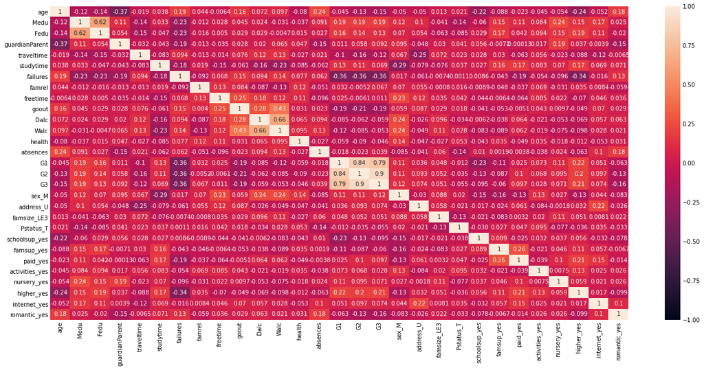

```python
plt.figure(figsize=(20, 10))
sns.heatmap(student.corr(), vmin=-1, vmax=1, annot=True)
#podwojne klikniecie na wykresie powieksza/zmniejsza wykres
```

```python
student.corr()
```

|  | age | Medu | Fedu | guardianParent | traveltime | studytime | failures | famrel | freetime | goout | Dalc | Walc | health | absences | G1 | G2 | G3 | sex_M | address_U | famsize_LE3 | Pstatus_T | schoolsup_yes | famsup_yes | paid_yes | activities_yes | nursery_yes | higher_yes | internet_yes | romantic_yes |
| --- | --- | --- | --- | --- | --- | --- | --- | --- | --- | --- | --- | --- | --- | --- | --- | --- | --- | --- | --- | --- | --- | --- | --- | --- | --- | --- | --- | --- | --- |
| age | 1.000000 | -0.117188 | -0.136948 | -0.372235 | -0.019129 | 0.037501 | 0.190119 | 0.044085 | -0.006409 | 0.163385 | 0.072043 | 0.096698 | -0.079983 | 0.237633 | -0.044867 | -0.125505 | -0.152773 | -0.049907 | -0.049954 | 0.012717 | 0.021327 | -0.224319 | -0.087629 | -0.023467 | -0.044779 | -0.054256 | -0.242522 | -0.052210 | 0.181820 |
| Medu | -0.117188 | 1.000000 | 0.622609 | 0.111057 | -0.142378 | 0.032667 | -0.230886 | -0.011602 | 0.028412 | 0.044817 | 0.023961 | -0.030860 | -0.037462 | 0.090790 | 0.186225 | 0.189926 | 0.190004 | 0.117324 | 0.101546 | -0.040895 | -0.142355 | -0.060184 | 0.147223 | 0.106825 | 0.083805 | 0.236951 | 0.145192 | 0.171331 | 0.024912 |
| Fedu | -0.136948 | 0.622609 | 1.000000 | 0.054395 | -0.150166 | -0.047341 | -0.229533 | -0.016011 | 0.005030 | 0.029451 | 0.028778 | -0.004725 | 0.015091 | 0.026984 | 0.164753 | 0.140383 | 0.125022 | 0.070197 | 0.054131 | -0.063086 | -0.085136 | 0.028543 | 0.172405 | 0.042436 | 0.094148 | 0.148691 | 0.190005 | 0.110054 | -0.019808 |
| guardianParent | -0.372235 | 0.111057 | 0.054395 | 1.000000 | -0.031833 | -0.043109 | -0.189430 | -0.013050 | -0.035332 | 0.028280 | 0.019708 | 0.065000 | 0.047219 | -0.150513 | 0.011311 | 0.058358 | 0.091525 | 0.095415 | -0.048045 | 0.029872 | 0.040954 | 0.055588 | -0.007108 | -0.000125 | 0.017103 | 0.194181 | 0.037184 | 0.003864 | -0.153489 |
| traveltime | -0.019129 | -0.142378 | -0.150166 | -0.031833 | 1.000000 | -0.083496 | 0.094242 | -0.012751 | -0.013856 | 0.076427 | 0.120747 | 0.134413 | -0.027271 | 0.020993 | -0.099799 | -0.161336 | -0.122169 | 0.067097 | -0.253160 | 0.071827 | 0.023470 | 0.027676 | 0.030084 | -0.062816 | 0.055504 | -0.022756 | -0.088427 | -0.119446 | -0.006534 |
| studytime | 0.037501 | 0.032667 | -0.047341 | -0.043109 | -0.083496 | 1.000000 | -0.179092 | 0.018855 | -0.146750 | -0.061460 | -0.164206 | -0.233989 | -0.084575 | -0.062364 | 0.130397 | 0.110514 | 0.069433 | -0.293114 | -0.079060 | -0.076041 | 0.036712 | 0.026554 | 0.160715 | 0.174651 | 0.083258 | 0.070320 | 0.173222 | 0.068836 | 0.071089 |
| failures | 0.190119 | -0.230886 | -0.229533 | -0.189430 | 0.094242 | -0.179092 | 1.000000 | -0.092054 | 0.068199 | 0.148452 | 0.094412 | 0.143772 | 0.076612 | 0.062298 | -0.362287 | -0.355301 | -0.364076 | 0.017239 | -0.060573 | -0.007422 | 0.001078 | 0.008621 | -0.042730 | -0.189724 | -0.053543 | -0.096133 | -0.337477 | -0.016034 | 0.125753 |
| famrel | 0.044085 | -0.011602 | -0.016011 | -0.013050 | -0.012751 | 0.018855 | -0.092054 | 1.000000 | 0.127189 | 0.083712 | -0.087369 | -0.126665 | 0.121517 | -0.050677 | 0.031878 | -0.005226 | 0.067478 | 0.070124 | 0.055293 | -0.000799 | 0.015565 | -0.008875 | -0.048066 | -0.036523 | 0.068603 | -0.030763 | 0.035380 | 0.008434 | -0.059452 |
| freetime | -0.006409 | 0.028412 | 0.005030 | -0.035332 | -0.013856 | -0.146750 | 0.068199 | 0.127189 | 1.000000 | 0.252442 | 0.177789 | 0.117305 | 0.107626 | -0.096153 | 0.025185 | -0.006131 | 0.010570 | 0.226598 | 0.121627 | 0.034553 | 0.041960 | -0.044458 | -0.006450 | -0.064093 | 0.085412 | 0.021968 | -0.070283 | 0.045929 | 0.035718 |
| goout | 0.163385 | 0.044817 | 0.029451 | 0.028280 | 0.076427 | -0.061460 | 0.148452 | 0.083712 | 0.252442 | 1.000000 | 0.279468 | 0.428249 | 0.030617 | 0.023424 | -0.190204 | -0.207336 | -0.189862 | 0.058597 | 0.086653 | 0.029441 | 0.018432 | -0.041236 | -0.053474 | -0.005083 | 0.042640 | 0.009650 | -0.048683 | 0.070418 | 0.029345 |
| Dalc | 0.072043 | 0.023961 | 0.028778 | 0.019708 | 0.120747 | -0.164206 | 0.094412 | -0.087369 | 0.177789 | 0.279468 | 1.000000 | 0.657078 | 0.064754 | 0.093684 | -0.085444 | -0.061778 | -0.059338 | 0.236235 | -0.026261 | 0.096455 | -0.033534 | -0.006158 | -0.038256 | 0.063708 | -0.021198 | -0.053018 | -0.069137 | 0.057243 | 0.062997 |
| Walc | 0.096698 | -0.030860 | -0.004725 | 0.065000 | 0.134413 | -0.233989 | 0.143772 | -0.126665 | 0.117305 | 0.428249 | 0.657078 | 1.000000 | 0.094695 | 0.132254 | -0.122148 | -0.085488 | -0.053480 | 0.244770 | -0.048903 | 0.106312 | 0.027528 | -0.082594 | -0.088804 | 0.061704 | -0.018629 | -0.075369 | -0.097511 | 0.028088 | 0.021267 |
| health | -0.079983 | -0.037462 | 0.015091 | 0.047219 | -0.027271 | -0.084575 | 0.076612 | 0.121517 | 0.107626 | 0.030617 | 0.064754 | 0.094695 | 1.000000 | -0.026931 | -0.059428 | -0.090170 | -0.046499 | 0.142937 | -0.047033 | -0.027173 | 0.052538 | -0.043316 | 0.034591 | -0.048814 | 0.035149 | -0.017982 | -0.011658 | -0.052756 | 0.030692 |
| absences | 0.237633 | 0.090790 | 0.026984 | -0.150513 | 0.020993 | -0.062364 | 0.062298 | -0.050677 | -0.096153 | 0.023424 | 0.093684 | 0.132254 | -0.026931 | 1.000000 | -0.017615 | -0.022578 | 0.039091 | -0.084922 | -0.041289 | 0.060150 | -0.137274 | 0.010472 | 0.001939 | -0.003770 | -0.038347 | 0.024189 | -0.063255 | 0.099705 | 0.183701 |
| G1 | -0.044867 | 0.186225 | 0.164753 | 0.011311 | -0.099799 | 0.130397 | -0.362287 | 0.031878 | 0.025185 | -0.190204 | -0.085444 | -0.122148 | -0.059428 | -0.017615 | 1.000000 | 0.841665 | 0.794055 | 0.114233 | 0.036434 | 0.047930 | -0.011897 | -0.232337 | -0.110930 | 0.025472 | 0.072980 | 0.105292 | 0.216779 | 0.050672 | -0.063189 |
| G2 | -0.125505 | 0.189926 | 0.140383 | 0.058358 | -0.161336 | 0.110514 | -0.355301 | -0.005226 | -0.006131 | -0.207336 | -0.061778 | -0.085488 | -0.090170 | -0.022578 | 0.841665 | 1.000000 | 0.902783 | 0.105832 | 0.092621 | 0.052345 | -0.034529 | -0.132018 | -0.086776 | 0.101356 | 0.068366 | 0.094521 | 0.204050 | 0.096647 | -0.131059 |
| G3 | -0.152773 | 0.190004 | 0.125022 | 0.091525 | -0.122169 | 0.069433 | -0.364076 | 0.067478 | 0.010570 | -0.189862 | -0.059338 | -0.053480 | -0.046499 | 0.039091 | 0.794055 | 0.902783 | 1.000000 | 0.117593 | 0.073983 | 0.050508 | -0.054532 | -0.094816 | -0.060494 | 0.097211 | 0.027787 | 0.070609 | 0.214211 | 0.074005 | -0.155605 |
| sex_M | -0.049907 | 0.117324 | 0.070197 | 0.095415 | 0.067097 | -0.293114 | 0.017239 | 0.070124 | 0.226598 | 0.058597 | 0.236235 | 0.244770 | 0.142937 | -0.084922 | 0.114233 | 0.105832 | 0.117593 | 1.000000 | -0.030348 | 0.087890 | 0.019792 | -0.150371 | -0.162079 | -0.133265 | 0.126519 | 0.027215 | -0.130976 | 0.044044 | -0.082740 |
| address_U | -0.049954 | 0.101546 | 0.054131 | -0.048045 | -0.253160 | -0.079060 | -0.060573 | 0.055293 | 0.121627 | 0.086653 | -0.026261 | -0.048903 | -0.047033 | -0.041289 | 0.036434 | 0.092621 | 0.073983 | -0.030348 | 1.000000 | 0.058371 | -0.020559 | -0.016739 | -0.024309 | 0.060720 | -0.083658 | -0.001789 | 0.032228 | 0.222043 | -0.025501 |
| famsize_LE3 | 0.012717 | -0.040895 | -0.063086 | 0.029872 | 0.071827 | -0.076041 | -0.007422 | -0.000799 | 0.034553 | 0.029441 | 0.096455 | 0.106312 | -0.027173 | 0.060150 | 0.047930 | 0.052345 | 0.050508 | 0.087890 | 0.058371 | 1.000000 | -0.132204 | -0.021272 | -0.083481 | 0.003235 | 0.020270 | 0.107535 | 0.051253 | 0.008132 | 0.021777 |
| Pstatus_T | 0.021327 | -0.142355 | -0.085136 | 0.040954 | 0.023470 | 0.036712 | 0.001078 | 0.015565 | 0.041960 | 0.018432 | -0.033534 | 0.027528 | 0.052538 | -0.137274 | -0.011897 | -0.034529 | -0.054532 | 0.019792 | -0.020559 | -0.132204 | 1.000000 | -0.037681 | 0.026662 | 0.046687 | 0.094795 | -0.076960 | -0.036366 | 0.034567 | -0.033347 |
| schoolsup_yes | -0.224319 | -0.060184 | 0.028543 | 0.055588 | 0.027676 | 0.026554 | 0.008621 | -0.008875 | -0.044458 | -0.041236 | -0.006158 | -0.082594 | -0.043316 | 0.010472 | -0.232337 | -0.132018 | -0.094816 | -0.150371 | -0.016739 | -0.021272 | -0.037681 | 1.000000 | 0.089099 | -0.024851 | 0.031946 | 0.036883 | 0.055930 | -0.031918 | -0.078233 |
| famsup_yes | -0.087629 | 0.147223 | 0.172405 | -0.007108 | 0.030084 | 0.160715 | -0.042730 | -0.048066 | -0.006450 | -0.053474 | -0.038256 | -0.088804 | 0.034591 | 0.001939 | -0.110930 | -0.086776 | -0.060494 | -0.162079 | -0.024309 | -0.083481 | 0.026662 | 0.089099 | 1.000000 | 0.259722 | -0.020826 | 0.045564 | 0.108583 | 0.056648 | -0.006734 |
| paid_yes | -0.023467 | 0.106825 | 0.042436 | -0.000125 | -0.062816 | 0.174651 | -0.189724 | -0.036523 | -0.064093 | -0.005083 | 0.063708 | 0.061704 | -0.048814 | -0.003770 | 0.025472 | 0.101356 | 0.097211 | -0.133265 | 0.060720 | 0.003235 | 0.046687 | -0.024851 | 0.259722 | 1.000000 | -0.038510 | 0.100819 | 0.209406 | 0.145092 | -0.013868 |
| activities_yes | -0.044779 | 0.083805 | 0.094148 | 0.017103 | 0.055504 | 0.083258 | -0.053543 | 0.068603 | 0.085412 | 0.042640 | -0.021198 | -0.018629 | 0.035149 | -0.038347 | 0.072980 | 0.068366 | 0.027787 | 0.126519 | -0.083658 | 0.020270 | 0.094795 | 0.031946 | -0.020826 | -0.038510 | 1.000000 | 0.007518 | 0.133656 | 0.025223 | 0.025769 |
| nursery_yes | -0.054256 | 0.236951 | 0.148691 | 0.194181 | -0.022756 | 0.070320 | -0.096133 | -0.030763 | 0.021968 | 0.009650 | -0.053018 | -0.075369 | -0.017982 | 0.024189 | 0.105292 | 0.094521 | 0.070609 | 0.027215 | -0.001789 | 0.107535 | -0.076960 | 0.036883 | 0.045564 | 0.100819 | 0.007518 | 1.000000 | 0.058684 | 0.020782 | 0.026329 |
| higher_yes | -0.242522 | 0.145192 | 0.190005 | 0.037184 | -0.088427 | 0.173222 | -0.337477 | 0.035380 | -0.070283 | -0.048683 | -0.069137 | -0.097511 | -0.011658 | -0.063255 | 0.216779 | 0.204050 | 0.214211 | -0.130976 | 0.032228 | 0.051253 | -0.036366 | 0.055930 | 0.108583 | 0.209406 | 0.133656 | 0.058684 | 1.000000 | 0.017459 | -0.099442 |
| internet_yes | -0.052210 | 0.171331 | 0.110054 | 0.003864 | -0.119446 | 0.068836 | -0.016034 | 0.008434 | 0.045929 | 0.070418 | 0.057243 | 0.028088 | -0.052756 | 0.099705 | 0.050672 | 0.096647 | 0.074005 | 0.044044 | 0.222043 | 0.008132 | 0.034567 | -0.031918 | 0.056648 | 0.145092 | 0.025223 | 0.020782 | 0.017459 | 1.000000 | 0.100373 |
| romantic_yes | 0.181820 | 0.024912 | -0.019808 | -0.153489 | -0.006534 | 0.071089 | 0.125753 | -0.059452 | 0.035718 | 0.029345 | 0.062997 | 0.021267 | 0.030692 | 0.183701 | -0.063189 | -0.131059 | -0.155605 | -0.082740 | -0.025501 | 0.021777 | -0.033347 | -0.078233 | -0.006734 | -0.013868 | 0.025769 | 0.026329 | -0.099442 | 0.100373 | 1.000000 |

## Próba porównania średnich wyników G1, G2 i G3 osób, które nie zrezygnowały z próby zaliczenia

Porównanie ze sobą średnich wyników zaliczeń może pomóc w określeniu, czy któryś z etapów (pierwszy semestr, drugi semestr, egzaminy końcowe) jest zauważalnie trudniejszy od innych. Tutaj dane zostaną ograniczone do osób, które uzyskały przynajmniej 1 punkt z G3. Takie ograniczenie nie dość, że potencjalnie da bardziej interpretowalne wyniki, to również pozwala pozbyć się problematycznego punktu 0 w G3, który koncentruje w sobie 10% całej populacji badanych uczniów.

Jedną z metod porównana ze sobą śrenich kilku różnych pomiarów jednego zjawiska jest Analiza Wariancji Powtórzonych Pomiarów (rANOVA). Metoda ta ma takie same założenia jak zwykła ANOVA. Pierwszym krokiem analizy będzie sprawdzenie normalności G1, G2 i G3 testem Shapiro-Wilka na standardowym poziomie istotności równym 0.05.

```python
BezZer=student[student.G3!=0]
```

```python
shapiroG1 = stats.shapiro(BezZer.G1)
shapiroG2 = stats.shapiro(BezZer.G2)
shapiroG3 = stats.shapiro(BezZer.G3)
print("p-wartość testu Shapiro-Wilka dla G1: ", shapiroG1[1])
print("p-wartość testu Shapiro-Wilka dla G2: ", shapiroG2[1])
print("p-wartość testu Shapiro-Wilka dla G3: ", shapiroG3[1])
```

```
p-wartość testu Shapiro-Wilka dla G1:  0.00017225339252036065
p-wartość testu Shapiro-Wilka dla G2:  0.0001354700798401609
p-wartość testu Shapiro-Wilka dla G3:  0.00040870008524507284
```

Wszystkie trzy testy orzekły, że na poziomie istotności 0.05, należy odrzucić hipotezę zerową, że wyniki G1, G2 lub G3 pochodzą z rozkładów normalnych. W takiej sytuacji pozostaje spróbować wykonać transformację danych. Pierwszym podejściem będzie nałożenie logarytmu naturalnego na każdą wartość G1, G2 i G3.

```python
shapiroLogG1 = stats.shapiro(np.log(BezZer.G1))
shapiroLogG2 = stats.shapiro(np.log(BezZer.G2))
shapiroLogG3 = stats.shapiro(np.log(BezZer.G3))
print("p-wartość testu Shapiro-Wilka dla log(G1): ", shapiroLogG1[1])
print("p-wartość testu Shapiro-Wilka dla log(G2): ", shapiroLogG2[1])
print("p-wartość testu Shapiro-Wilka dla log(G3): ", shapiroLogG3[1])
```

```
p-wartość testu Shapiro-Wilka dla log(G1):  1.029790496431815e-06
p-wartość testu Shapiro-Wilka dla log(G2):  4.640459337679204e-06
p-wartość testu Shapiro-Wilka dla log(G3):  1.4184382735038525e-06
```

Ponownie, test Shapiro-Wilka, na poziomie istotności równym 0.05, orzeka, że dane po transformacji logarytmicznej wciąż nie należą do rozkładów normalnych. Drugim potencjalnym rozwiązaniem jest wzięcie pierwiastka z wyników.

```python
shapiroSqrtG1 = stats.shapiro(np.sqrt(BezZer.G1))
shapiroSqrtG2 = stats.shapiro(np.sqrt(BezZer.G2))
shapiroSqrtG3 = stats.shapiro(np.sqrt(BezZer.G3))
print("p-wartość testu Shapiro-Wilka dla sqrt(G1): ", shapiroSqrtG1[1])
print("p-wartość testu Shapiro-Wilka dla sqrt(G2): ", shapiroSqrtG2[1])
print("p-wartość testu Shapiro-Wilka dla sqrt(G3): ", shapiroSqrtG3[1])
```

```
p-wartość testu Shapiro-Wilka dla sqrt(G1):  0.00033339436049573123
p-wartość testu Shapiro-Wilka dla sqrt(G2):  0.0005321669741533697
p-wartość testu Shapiro-Wilka dla sqrt(G3):  0.000817475956864655
```

Ponownie, test Shapiro-Wilka, na poziomie istotności równym 0.05, orzeka, że dane po nałożeniu pierwiastka wciąż nie należą do rozkładów normalnych.

Ostatnim podejściem będzie próba dopasowania transformacji Boxa-Coxa przy parametrze $\lambda$ różnym od zera. Do sprawdzenia, jaka wartość lambda jest odpowiednia, przydadzą się histogramy oraz wykresy pudełkowe.

```python
fig = go.Figure(data=[go.Histogram(x=BezZer.G1)])



fig.update_layout(
    title_text="Rozkład wyników G1 uczniów, którzy nie zrezygnowali",
     xaxis_title_text='Wynik',
     yaxis_title_text='Liczba osób')


fig.show()
```

[interactive chart not shown]

```python
fig = go.Figure(data=[go.Histogram(x=BezZer.G2)])


fig.update_layout(
    title_text="Rozkład wyników G2 uczniów, którzy nie zrezygnowali",
     xaxis_title_text='Wynik',
     yaxis_title_text='Liczba osób')


fig.show()
```

[interactive chart not shown]

```python
fig = go.Figure(data=[go.Histogram(x=BezZer.G3)])


fig.update_layout(
    title_text="Rozkład wyników G3 uczniów, którzy nie zrezygnowali",
     xaxis_title_text='Wynik',
     yaxis_title_text='Liczba osób')


fig.show()
```

[interactive chart not shown]

```python
fig = go.Figure()
fig.add_trace(go.Box(y=BezZer.G1, name="G1"))
fig.add_trace(go.Box(y=BezZer.G2, name="G2"))
fig.add_trace(go.Box(y=BezZer.G3, name="G3"))

fig.update_layout(
    title_text="Boxploty dla uczniów, którzy nie zrezygnowali",
     xaxis_title_text='Zaliczenie')

fig.show()
```

[interactive chart not shown]

Z wykresów można odczytać, że dane są prawostronnie asymetryczne (przeważają mniejsze obserwacje). Potrzebna będzie zatem transformacja wklęsła, która charakteryzuje się wartością $\lambda$ mniejszą od 1.

```python
lam=0.7
shapiroBCG1 = stats.shapiro(((BezZer.G1)**lam-1)/lam)
shapiroBCG2 = stats.shapiro(((BezZer.G2)**lam-1)/lam)
shapiroBCG3 = stats.shapiro(((BezZer.G3)**lam-1)/lam)
print('Dla lambdy równej ', lam,":")
print("p-wartość testu Shapiro-Wilka po transformacji Boxa-Coxa dla G1: ", shapiroBCG1[1])
print("p-wartość testu Shapiro-Wilka po transformacji Boxa-Coxa dla G2: ", shapiroBCG2[1])
print("p-wartość testu Shapiro-Wilka po transformacji Boxa-Coxa dla G3: ", shapiroBCG3[1])
```

```
Dla lambdy równej  0.7 :
p-wartość testu Shapiro-Wilka po transformacji Boxa-Coxa dla G1:  0.0005446702125482261
p-wartość testu Shapiro-Wilka po transformacji Boxa-Coxa dla G2:  0.0006399232661351562
p-wartość testu Shapiro-Wilka po transformacji Boxa-Coxa dla G3:  0.0015167611418291926
```

Próba dobrania wartości parametru $\lambda$ tak, by uzyskać dane pochodzące z rozkładu normalnego, zakończyła się niepowodzeniem. Rezultat ten był do przewidzenia - transformacja Boxa-Coxa rzadko sprawdza się w przypadku danych dyskretnych.

Należy wyciągnąć wniosek, że rANOVA nie pasuje do danych. Pozostaje zatem sięgnąć do innych, mniej standardowych metod. Jedną z nich jest test Friedmana. Nie wymaga on założeń metody ANOVA, lecz w przypadku małej liczby grup (poniżej 5) należy mieć świadomość, że oszacowanie p-wartości testu może być niedokładne.

```python
print("Wynik testu Friedmana:")
stats.friedmanchisquare(BezZer.G1,BezZer.G2,BezZer.G3)
```

```
Wynik testu Friedmana:
```

```
FriedmanchisquareResult(statistic=9.25707814269562, pvalue=0.009769020524334199)
```

Na podstawie testu Friedmana na poziomie istotności 0.05 należy odrzucić hipotezę zerową o równości wszystkich trzech średnich wyników G1, G2 i G3. W celu wykrycia, które grupy są od siebie różne, zastosowana zostanie metoda Dunna analizy post hoc.

```python
print('Wynik procedury post hoc Dunna:')
scikit_posthocs.posthoc_dunn([BezZer.G1,BezZer.G2,BezZer.G3], p_adjust = "holm")
```

```
Wynik procedury post hoc Dunna:
```

|  | 1 | 2 | 3 |
| --- | --- | --- | --- |
| 1 | 1.000000 | 1.0 | 0.678838 |
| 2 | 1.000000 | 1.0 | 1.000000 |
| 3 | 0.678838 | 1.0 | 1.000000 |

Wyniki przedstawione w tabeli powyżej opisują p-wartości otrzymane w wyniku porównania metodą Dunna parami każdej grupy. Wyniki na przekątnej pokazują porównania każdej grupy z samą sobą i nie wnoszą żadnej informacji. Wykorzystana tu analiza post hoc bazuje na porównaniach wielokrotnych, w celu korekty p-wartości zastosowano poprawkę Holma zamiast standardowej poprawki Bonferoniego. Mimo to wyniki przedstawiają sytuację, w której wszystkie porównania wskazują brak różnic między grupami. Rezultat ten jest sprzeczny z wynikami otrzymanymi z testu Friedmana. Mogą być dwie główne przyczyny tej rozbieżności. Pierwszą jest wspomniane już wcześniej niedoszacowanie p-wartości testu Friedmana, gdy porównuje się ze sobą małą liczbę grup. Drugą przyczyną może być niska moc testu w analizie Dunna, która nie pozwala na odrzucenie żadnych hipotez zerowych o braku istotnych różnic między grupami. Należy zatem wnioskować, że równość G1, G2 i G3 jest możliwa, choć jest niepewna.

## Predykcja G3 bez użycia G1 i G2

W tej sekcji przedstawione zostanie jedno z możliwych podejść przewidzenia wyniku G3 ucznia, korzystając tylko z dostępnych danych z wyłączeniem wyników G1 i G2. Wykorzystany zostanie model Extreme Boosting (XGBoost), który wykorzystuje drzewa losowe. Z tego powodu skalowanie zmiennych jest niepotrzebne. Do wyznaczenia hiperparametrów modelu wykorzystane zostanie połączenie kroswalidacji z 5 foldami i losowe przeszukiwanie siatki hiperparametrów. Model zostanie wyuczony przy użyciu 80% zbioru danych wybranego przez losowanie. Pozostałe 20% posłuży jako zbiór testowy. Metryką błędu oceniającą jakość predykcji będzie Root Mean Squared Error (RMSE).

Zmienne zależne, które zostaną użyte w modelu to: liczba porażek ('failures'), indykator płci męskiej ('sex_M'), stopień wykształcenia matki ('Medu'), stopień częstości wychodzenia ucznia ze znajomymi ('goout'), indykator planowania pójścia na studia ('higher_yes'), stopień czasu spędzanego na nauce('studytime'), stopień spożycia alkoholu w weekendy ('Walc').

```python
X_train, X_test, y_train, y_test = train_test_split(student[['failures','sex_M','Medu','goout','higher_yes','studytime','Walc']], student.G3,
                                                                train_size=0.8, test_size=0.2,
                                                                random_state=0)

paramsXG = {
        'min_child_weight': [1, 5, 10],
        'gamma': [0,0.5,1, 5],
        'subsample': [0.7, 1.0],
        'colsample_bytree': [0.7, 1.0],
        'max_depth': [4, 5,6,7],
        'reg_lambda' : [1,2,3],
        'eta' : [0.3,0.6]
        }

XGbReg = XGBRegressor(n_estimators=1000, learning_rate=0.01, random_state=1001)
```

```python
folds = 5
param_comb = 150

random_search = RandomizedSearchCV(XGbReg, paramsXG, n_jobs=1, cv=folds, n_iter=param_comb, scoring='neg_root_mean_squared_error',random_state=1001)

random_search.fit(X_train, y_train)

print('\n Best hyperparameters:')
print(random_search.best_params_)
results = pd.DataFrame(random_search.cv_results_)
```

[output not shown]

```python
XGbest=XGBRegressor(n_estimators=1000, learning_rate=0.01, subsample= 1,reg_lambda=2, min_child_weight= 1, max_depth= 4, gamma= 5,eta=0.3, colsample_bytree= 1)
XGbest.fit(X_train,y_train)


XGbestpred = XGbest.predict(X_test)


mse_XGbest = mean_squared_error(XGbestpred,y_test)
rmse_XGbest=np.sqrt(mse_XGbest)
print("Wartość RMSE dla tego modelu wyniosła: ", rmse_XGbest)
```

```
Wartość RMSE dla tego modelu wyniosła:  4.58592881499018
```

Model XGBoost w wybranymi hiperparametrami osiągnął na zbiorze testowym wartość RMSE równą 4.58592881499018. Wynik ten może wydawać się mało zadowalający. Można jednak spojrzeć, dla jakich przypadków metoda dała najgorsze wyniki.

```python
pd.set_option('display.max_rows', None)
wyniki_predykcji = list(zip(XGbestpred,y_test.values,np.abs((XGbestpred-y_test).values)))
wyniki_predykcji = pd.DataFrame(wyniki_predykcji, columns=['predykcja','G3','|G3-predykcja|'])
print('Tabela z wynikami G3, predykcją i błędem absolutnym predykcji na zbiorze testowym')
wyniki_predykcji.sort_values(by=['|G3-predykcja|'],ascending=False).head(10)
```

```
Tabela z wynikami G3, predykcją i błędem absolutnym predykcji na zbiorze testowym
```

|  | predykcja | G3 | \|G3-predykcja\| |
| --- | --- | --- | --- |
| 50 | 13.744617 | 0 | 13.744617 |
| 15 | 12.383199 | 0 | 12.383199 |
| 43 | 10.421211 | 0 | 10.421211 |
| 42 | 7.765092 | 18 | 10.234908 |
| 35 | 13.719908 | 5 | 8.719908 |
| 36 | 5.892992 | 14 | 8.107008 |
| 48 | 7.808786 | 0 | 7.808786 |
| 24 | 7.269135 | 0 | 7.269135 |
| 67 | 8.464959 | 15 | 6.535041 |
| 3 | 12.424492 | 6 | 6.424492 |

```python
X_train, X_test, y_train, y_test = train_test_split(BezZer[['failures','sex_M','Medu','goout','higher_yes','studytime','Walc']], BezZer.G3,
                                                                train_size=0.8, test_size=0.2,
                                                                random_state=0)

paramsXG = {
        'min_child_weight': [1, 5, 10],
        'gamma': [0,0.5,1, 5],
        'subsample': [0.7, 1.0],
        'colsample_bytree': [0.7, 1.0],
        'max_depth': [4, 5,6,7],
        'reg_lambda' : [1,2,3],
        'eta' : [0.3,0.6]
        }

XGbReg = XGBRegressor(n_estimators=1000, learning_rate=0.01, random_state=1001)
```

```python
folds = 5
param_comb = 150

random_search = RandomizedSearchCV(XGbReg, paramsXG, n_jobs=1, cv=folds, n_iter=param_comb, scoring='neg_root_mean_squared_error',random_state=1001)

random_search.fit(X_train, y_train)

print('\n Best hyperparameters:')
print(random_search.best_params_)
results = pd.DataFrame(random_search.cv_results_)
```

[output not shown]

```python
XGbest=XGBRegressor(n_estimators=1000, learning_rate=0.01, subsample= 1,reg_lambda=2, min_child_weight= 1, max_depth= 4, gamma= 5,eta=0.3, colsample_bytree= 1)
XGbest.fit(X_train,y_train)


XGbestpred = XGbest.predict(X_test)


mse_XGbest = mean_squared_error(XGbestpred,y_test)
rmse_XGbest=np.sqrt(mse_XGbest)
print("Wartość RMSE dla tego modelu wyniosła: ", rmse_XGbest)
```

```
Wartość RMSE dla tego modelu wyniosła:  2.977496918644765
```

```python
pd.set_option('display.max_rows', None)
wyniki_predykcji = list(zip(XGbestpred,y_test.values,np.abs((XGbestpred-y_test).values)))
wyniki_predykcji = pd.DataFrame(wyniki_predykcji, columns=['predykcja','G3','|G3-predykcja|'])
print('Tabela z wynikami G3, predykcją i błędem absolutnym predykcji na zbiorze testowym dla uczniów z wynikiem G3 większym od 0')
wyniki_predykcji.sort_values(by=['|G3-predykcja|'],ascending=False).head(10)
```

```
Tabela z wynikami G3, predykcją i błędem absolutnym predykcji na zbiorze testowym dla uczniów z wynikiem G3 większym od 0
```

|  | predykcja | G3 | \|G3-predykcja\| |
| --- | --- | --- | --- |
| 11 | 11.785089 | 19 | 7.214911 |
| 58 | 14.591704 | 8 | 6.591704 |
| 13 | 11.081448 | 17 | 5.918552 |
| 32 | 11.185311 | 17 | 5.814689 |
| 51 | 13.575088 | 19 | 5.424912 |
| 50 | 9.807220 | 15 | 5.192780 |
| 43 | 13.015603 | 8 | 5.015603 |
| 22 | 12.922090 | 8 | 4.922090 |
| 41 | 10.820795 | 6 | 4.820795 |
| 14 | 11.553019 | 16 | 4.446981 |

Model ten wykazał się dużo lepszą skutecznością. Wynik RMSE poniżej 3 wydaje się być dość dobrym rozwiązaniem problemu predykcji wyników uczniów przy tak mało szczegółowych danych.

## Wyznaczenie grupy uczniów słabszych przy pomocy analizy skupień

W tej części wykorzystana zostanie metoda k średnich do stworzenia pogrupowania uczniów względem wyników. Pod uwagę zostaną wzięte wyniki G1 i G3. Przy wyborze liczby klastrów jako funkcja straty zostanie użyta suma kwadratów odległości punktów do przypisanych im finalnych centroidów (WCSS).

```python
wcss=[]
for i in range(1,11):
    kmeans = KMeans(n_clusters= i, init='k-means++', random_state=0)
    kmeans.fit(dane[['G1','G3']])
    wcss.append(kmeans.inertia_)
```

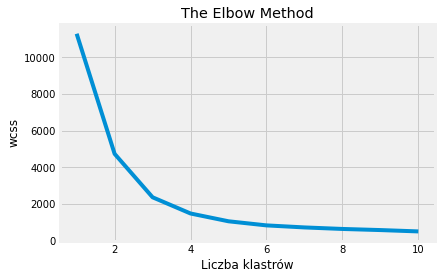

```python
plt.plot(range(1,11), wcss)
plt.title('The Elbow Method')
plt.xlabel('Liczba klastrów')
plt.ylabel('wcss')
plt.show()
```

Z powyższego wykresu można odczytać, że optymalną liczbą klastrów jest liczba 4.

```python
kmeansmodel = KMeans(n_clusters= 4, init='k-means++', random_state=0)
y_kmeans= kmeansmodel.fit_predict(dane[['G1','G3']])
```

```python
dane.insert(len(dane.columns),'klaster',y_kmeans,True)
```

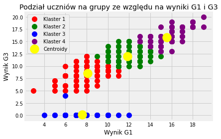

```python
plt.scatter(dane[dane['klaster']==0]['G1'], dane[dane['klaster']==0]['G3'], s = 100, c = 'red', label = 'Klaster 1')
plt.scatter(dane[dane['klaster']==1]['G1'], dane[dane['klaster']==1]['G3'], s = 100, c = 'green', label = 'Klaster 2')
plt.scatter(dane[dane['klaster']==2]['G1'], dane[dane['klaster']==2]['G3'], s = 100, c = 'blue', label = 'Klaster 3')
plt.scatter(dane[dane['klaster']==3]['G1'], dane[dane['klaster']==3]['G3'], s = 100, c = 'purple', label = 'Klaster 4')
plt.scatter(kmeansmodel.cluster_centers_[:, 0], kmeansmodel.cluster_centers_[:, 1], s = 300, c = 'yellow', label = 'Centroidy')
plt.title('Podział uczniów na grupy ze względu na wyniki G1 i G3')
plt.xlabel('Wynik G1')
plt.ylabel('Wynik G3')
plt.legend()
plt.show()
```

Powyższy wykres obrazuje 4 grupy:

- niebieska to osoby, które zrezygnowały,
- czerwona to osoby słabsze,
- zielona to osoby średnie,
- fioletowa to osoby zdolne.

Z tego podziału wyłamuje się jedna osoba, która mimo słabych, lecz niezerowych wyników, wciąż jest w grupie niebieskiej. Można by było zatem uznać, że osoba słabsza to uczeń należący do dwóch pierwszych klastrów albo tylko do klastra drugiego.